# NYPD Shooting Incident Data Report

T.Umeno

12/28/2021

## Description of the data

This data is the list of every shooting incident that occurred in NYC going back to 2006 through the end of the previous calendar year. The original data can be found at https://catalog.data.gov/dataset/nypd-shooting-incident-data-historic.

The direct link of csv data is below:

```r
data_url <-"https://data.cityofnewyork.us/api/views/833y-fsy8/rows.csv"
```

R packages used in this analysis are below:

```r
library(tidyverse)
```

```r
library(ggfortify)
library(ggplot2)
knitr::opts_chunk$set(echo = TRUE)
```

## Summary of the data

This data has 19 columns and 23.6k rows, including features like “Exact date of the shooting incident”, “Location of the shooting incident”, “Perpetrator’s sex description”, “Victim’s race description”, and so on.

```r
Incident_data <- read_csv(data_url)
```

```r
summary(Incident_data)
```

```
##   INCIDENT_KEY        OCCUR_DATE         OCCUR_TIME           BORO
##  Min.   :  9953245   Length:23585       Length:23585      Length:23585
##  1st Qu.: 55322804   Class :character   Class1:hms        Class :character
##  Median : 83435362   Mode  :character   Class2:difftime   Mode  :character
##  Mean   :102280741                      Mode  :numeric
##  3rd Qu.:150911774
##  Max.   :230611229
##
##     PRECINCT      JURISDICTION_CODE LOCATION_DESC      STATISTICAL_MURDER_FLAG
##  Min.   :  1.00   Min.   :0.000     Length:23585       Mode :logical
##  1st Qu.: 44.00   1st Qu.:0.000     Class :character   FALSE:19085
##  Median : 69.00   Median :0.000     Mode  :character   TRUE :4500
##  Mean   : 66.21   Mean   :0.333
##  3rd Qu.: 81.00   3rd Qu.:0.000
##  Max.   :123.00   Max.   :2.000
##                   NA's   :2
##  PERP_AGE_GROUP       PERP_SEX          PERP_RACE         VIC_AGE_GROUP
##  Length:23585       Length:23585       Length:23585       Length:23585
##  Class :character   Class :character   Class :character   Class :character
##  Mode  :character   Mode  :character   Mode  :character   Mode  :character
##
##
##
##
##    VIC_SEX            VIC_RACE           X_COORD_CD        Y_COORD_CD
##  Length:23585       Length:23585       Min.   : 914928   Min.   :125757
##  Class :character   Class :character   1st Qu.: 999925   1st Qu.:182539
##  Mode  :character   Mode  :character   Median :1007654   Median :193470
##                                        Mean   :1009379   Mean   :207300
##                                        3rd Qu.:1016782   3rd Qu.:239163
##                                        Max.   :1066815   Max.   :271128
##
##     Latitude       Longitude        Lon_Lat
##  Min.   :40.51   Min.   :-74.25   Length:23585
##  1st Qu.:40.67   1st Qu.:-73.94   Class :character
##  Median :40.70   Median :-73.92   Mode  :character
##  Mean   :40.74   Mean   :-73.91
##  3rd Qu.:40.82   3rd Qu.:-73.88
##  Max.   :40.91   Max.   :-73.70
##
```

### Transform the date type

OCCUR_DATE is transformed to the date type which will be used for a time series graph later.

```r
Incident_data$year_month <- strftime(as.Date(Incident_data$OCCUR_DATE, "%m/%d/%Y"), "%Y-%m")
```

Some columns are omitted for this analysis.

```r
mydata = select(Incident_data, -c(X_COORD_CD, Y_COORD_CD, Lon_Lat, Latitude,  Longitude, LOCATION_DESC, OCCUR_DATE, PRECINCT, JURISDICTION_CODE, STATISTICAL_MURDER_FLAG))
summary(mydata)
```

```
##   INCIDENT_KEY        OCCUR_TIME           BORO           PERP_AGE_GROUP
##  Min.   :  9953245   Length:23585      Length:23585       Length:23585
##  1st Qu.: 55322804   Class1:hms        Class :character   Class :character
##  Median : 83435362   Class2:difftime   Mode  :character   Mode  :character
##  Mean   :102280741   Mode  :numeric
##  3rd Qu.:150911774
##  Max.   :230611229
##    PERP_SEX          PERP_RACE         VIC_AGE_GROUP        VIC_SEX
##  Length:23585       Length:23585       Length:23585       Length:23585
##  Class :character   Class :character   Class :character   Class :character
##  Mode  :character   Mode  :character   Mode  :character   Mode  :character
##
##
##
##    VIC_RACE          year_month
##  Length:23585       Length:23585
##  Class :character   Class :character
##  Mode  :character   Mode  :character
##
##
##
```

## Visualizations and analysis

### The number of incidents in time series

The line graph below indicates the number of incidents through 2006-2020. We can see a seasonable periodic trend in this graph. Most surprisingly, there is a huge spike in the middle of 2020. It is considered that the COVID pandemic affects a lot on numbers of shooting incidents in NYC.

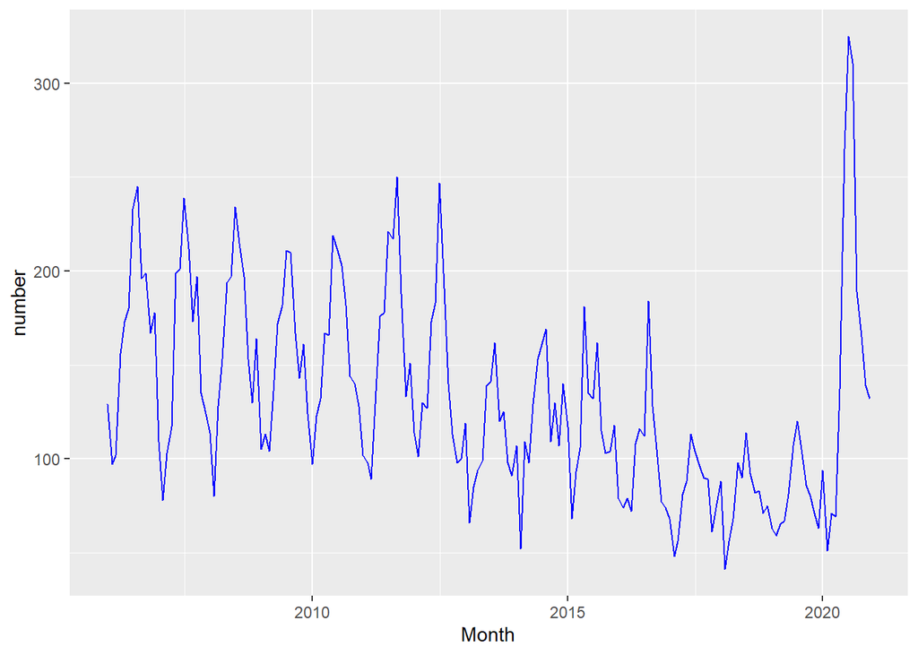

```r
trend_data <- mydata %>%
  group_by(year_month) %>%
  summarize(n=n()) %>%
  ungroup()

data_ts<-ts(trend_data$n,frequency=12,start=c(2006,1))
autoplot(data_ts, ts.colour = 'blue', xlab='Month', ylab='number')
```

### The number of victims in each age group

Next, the bar graph below shows that the number of victims in each age group between 2006 and 2020.

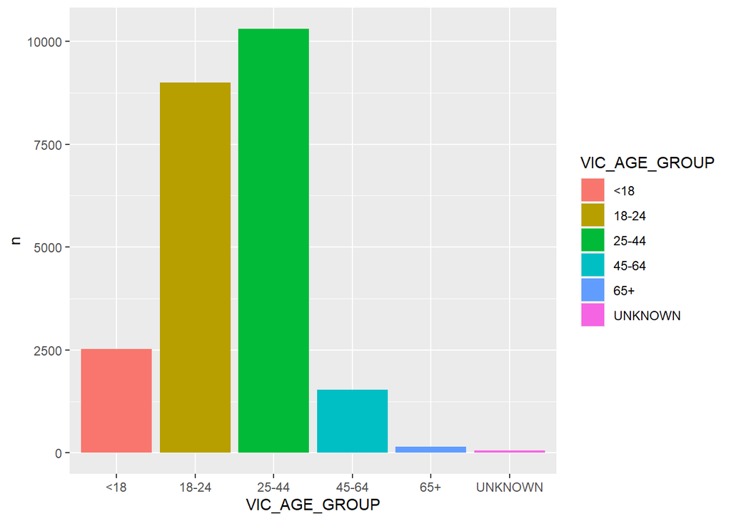

```r
age_data <- mydata %>%
  group_by(VIC_AGE_GROUP) %>%
  summarize(n=n()) %>%
  ungroup()

ggplot(age_data, aes(x=VIC_AGE_GROUP, y=n, fill=VIC_AGE_GROUP))  + geom_bar(stat = "identity", position = "dodge")
```

### The number of victims in each racial group

This bar graph shows that the number of victims in each racial group between 2006 and 2020.

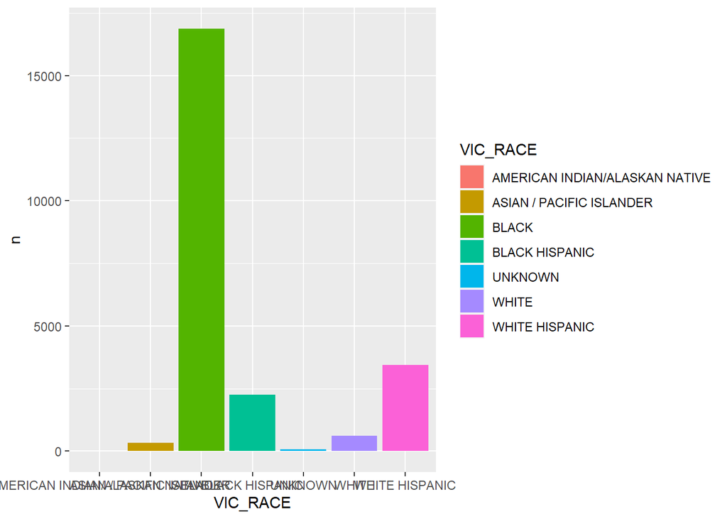

```r
race_data <- mydata %>%
  group_by(VIC_RACE) %>%
  summarize(n=n()) %>%
  ungroup()

ggplot(race_data, aes(x=VIC_RACE, y=n, fill=VIC_RACE))  + geom_bar(stat = "identity", position = "dodge")
```

## Modeling data

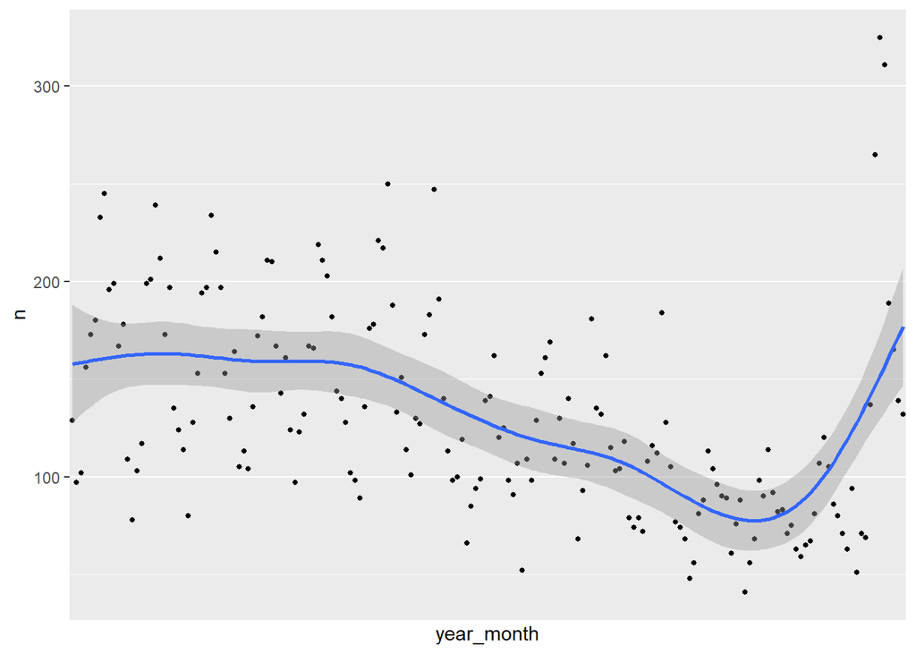

```r
trend_data_2 <- trend_data %>%
  mutate(num = row_number())

g1 <- ggplot(data = trend_data_2, aes(x = num, y = n))+
    geom_point(size = 1)+
  stat_smooth(method = "gam", se = TRUE)+
  scale_x_discrete("year_month")
plot(g1)
```